# Nienadzorowana Detekcja Fraudów Bankowych

## 16.2 Finalna krzywa ROC — wszystkie modele

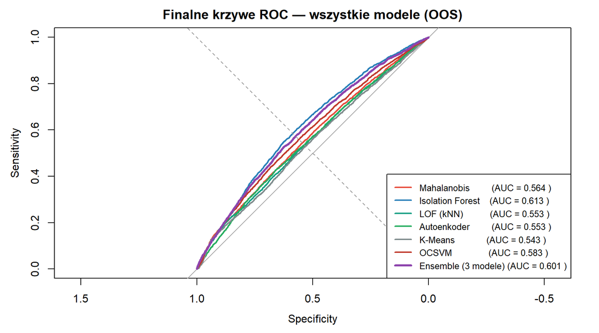

```r
plot(roc_mahala,   col="#e74c3c", lwd=2, main="Finalne krzywe ROC — wszystkie modele (OOS)")
plot(roc_iof,      add=TRUE, col="#2980b9", lwd=2)
plot(roc_lof,      add=TRUE, col="#16a085", lwd=2)
plot(roc_ae,       add=TRUE, col="#27ae60", lwd=2)
plot(roc_kmeans,   add=TRUE, col="#7f8c8d", lwd=2)
plot(roc_ocsvm,    add=TRUE, col="#c0392b", lwd=2)
plot(roc_ensemble, add=TRUE, col="#8e44ad", lwd=3)
abline(0, 1, lty=2, col="grey60")
legend("bottomright", lwd=c(2,2,2,2,2,2,3), cex=0.82,
       col=c("#e74c3c","#2980b9","#16a085","#27ae60","#7f8c8d","#c0392b","#8e44ad"),
       legend=c(
  paste("Mahalanobis         (AUC =", round(auc(roc_mahala),3),")"),
  paste("Isolation Forest    (AUC =", round(auc(roc_iof),3),")"),
  paste("LOF (kNN)           (AUC =", round(auc(roc_lof),3),")"),
  paste("Autoenkoder         (AUC =", round(auc(roc_ae),3),")"),
  paste("K-Means             (AUC =", round(auc(roc_kmeans),3),")"),
  paste("OCSVM               (AUC =", round(auc(roc_ocsvm),3),")"),
  paste("Ensemble (3 modele) (AUC =", round(auc(roc_ensemble),3),")")))
```

# 17 Metryki Biznesowe

## 17.1 Krzywa Lift

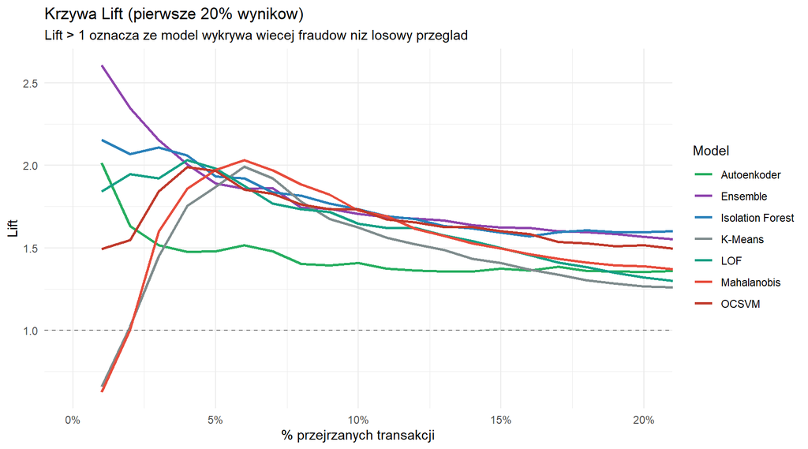

```r
compute_lift <- function(scores, labels, steps=100) {
  ord <- order(scores, decreasing=TRUE); labels <- labels[ord]
  n <- length(labels); n_fraud <- sum(labels=="Fraud")
  pct <- seq(1/steps,1,length.out=steps)
  tibble(pct_reviewed=pct*100,
         lift=sapply(pct, function(p) {
           k <- max(1, floor(p*n))
           sum(labels[1:k]=="Fraud") / (p*n_fraud) }))
}

bind_rows(
  compute_lift(score_mahala,  df_test_raw$fraud_bool) %>% mutate(model="Mahalanobis"),
  compute_lift(score_iof,     df_test_raw$fraud_bool) %>% mutate(model="Isolation Forest"),
  compute_lift(score_lof,     df_test_raw$fraud_bool) %>% mutate(model="LOF"),
  compute_lift(score_ae,      df_test_raw$fraud_bool) %>% mutate(model="Autoenkoder"),
  compute_lift(score_kmeans,  df_test_raw$fraud_bool) %>% mutate(model="K-Means"),
  compute_lift(score_ocsvm,   df_test_raw$fraud_bool) %>% mutate(model="OCSVM"),
  compute_lift(score_ensemble,df_test_raw$fraud_bool) %>% mutate(model="Ensemble")
) %>%
  ggplot(aes(pct_reviewed, lift, color=model)) +
  geom_line(linewidth=0.9) +
  geom_hline(yintercept=1, linetype="dashed", color="grey50") +
  scale_color_manual(values=c("Mahalanobis"="#e74c3c","Isolation Forest"="#2980b9",
    "LOF"="#16a085","Autoenkoder"="#27ae60","K-Means"="#7f8c8d",
    "OCSVM"="#c0392b","Ensemble"="#8e44ad")) +
  scale_x_continuous(labels=function(x) paste0(x,"%")) +
  coord_cartesian(xlim=c(0,20)) + theme_minimal() +
  labs(title="Krzywa Lift (pierwsze 20% wynikow)",
       subtitle="Lift > 1 oznacza ze model wykrywa wiecej fraudow niz losowy przeglad",
       x="% przejrzanych transakcji", y="Lift", color="Model")
```

## 17.2 AUC vs Recall@5% — efektywnosc operacyjna

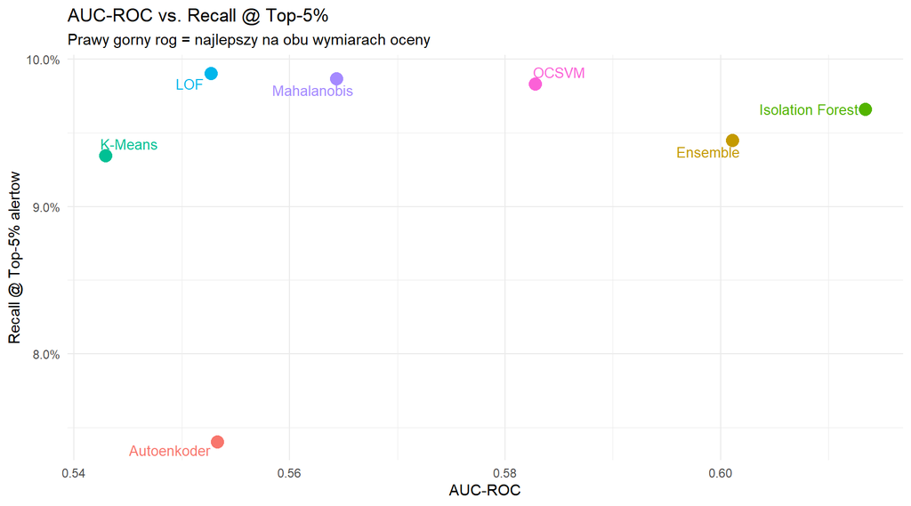

```r
tibble(
  Model   = c("Mahalanobis","Isolation Forest","LOF","Autoenkoder",
              "K-Means","OCSVM","Ensemble"),
  AUC     = c(auc(roc_mahala),auc(roc_iof),auc(roc_lof),auc(roc_ae),
              auc(roc_kmeans),auc(roc_ocsvm),auc(roc_ensemble)),
  Recall5 = c(recall_topk(score_mahala,  df_test_raw$fraud_bool),
              recall_topk(score_iof,     df_test_raw$fraud_bool),
              recall_topk(score_lof,     df_test_raw$fraud_bool),
              recall_topk(score_ae,      df_test_raw$fraud_bool),
              recall_topk(score_kmeans,  df_test_raw$fraud_bool),
              recall_topk(score_ocsvm,   df_test_raw$fraud_bool),
              recall_topk(score_ensemble,df_test_raw$fraud_bool))
) %>%
  ggplot(aes(AUC, Recall5, label=Model, color=Model)) +
  geom_point(size=4) +
  geom_text_repel(size=3.5, show.legend=FALSE) +
  scale_y_continuous(labels=percent) + theme_minimal() +
  theme(legend.position="none") +
  labs(title="AUC-ROC vs. Recall @ Top-5%",
       subtitle="Prawy gorny rog = najlepszy na obu wymiarach oceny",
       x="AUC-ROC", y="Recall @ Top-5% alertow")
```

# 18 Waznosc Zmiennych — Analiza Permutacyjna

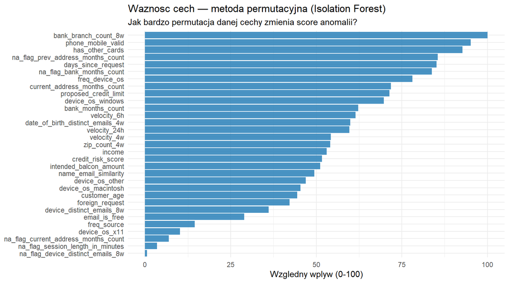

```r
imp_rec <- recipe(fraud_bool~., data=df_train_raw %>% select(all_of(all_features),fraud_bool)) %>%
  step_impute_median(all_numeric_predictors()) %>%
  step_dummy(all_nominal_predictors()) %>%
  step_zv(all_predictors()) %>%
  step_YeoJohnson(all_numeric_predictors()) %>%
  step_corr(all_numeric_predictors(), threshold=0.85) %>%
  step_normalize(all_numeric_predictors()) %>%
  prep()
df_imp      <- bake(imp_rec, new_data=df_train_raw) %>% select(-fraud_bool)
iso_imp     <- isolation.forest(df_imp, ntrees=100)
base_scores <- predict(iso_imp, df_imp)

imp_vals <- sapply(names(df_imp), function(col) {
  sh <- df_imp; sh[[col]] <- sample(sh[[col]])
  mean(abs(predict(iso_imp, sh) - base_scores))
})

tibble(Cecha=names(imp_vals), Waznosc=as.numeric(imp_vals)) %>%
  mutate(Waznosc=Waznosc/max(Waznosc)*100) %>%
  arrange(desc(Waznosc)) %>%
  ggplot(aes(reorder(Cecha, Waznosc), Waznosc)) +
  geom_col(fill="#2980b9", alpha=0.85) +
  coord_flip() + theme_minimal() +
  labs(title="Waznosc cech — metoda permutacyjna (Isolation Forest)",
       subtitle="Jak bardzo permutacja danej cechy zmienia score anomalii?",
       x=NULL, y="Wzgledny wplyw (0-100)")
```

```r
rm(imp_rec, df_imp, iso_imp, base_scores, imp_vals); gc(verbose=FALSE)
```

```
##             used   (Mb) gc trigger   (Mb)  max used   (Mb)
## Ncells   3800922  203.0   10666598  569.7  10666598  569.7
## Vcells 245661014 1874.3  667184043 5090.3 667167849 5090.1
```

# 19 Walidacja Bootstrapowa (20 Iteracji)

H2O Autoenkoder jest wykluczony z bootstrapu ze wzgledu na koszt obliczeniowy (trening sieci 20x wymagalby ~3-4 godzin). O jego stabilnosc wnioskuje się na podstawie walidacji krzyzowej przeprowadzonej podczas grid search

```r
run_boot_validation <- function(train_data, test_data) {
  rec <- recipe(fraud_bool~., data=train_data %>% select(all_of(all_features),fraud_bool)) %>%
    step_impute_median(all_numeric_predictors()) %>%
    step_dummy(all_nominal_predictors()) %>%
    step_zv(all_predictors()) %>%
    step_YeoJohnson(all_numeric_predictors()) %>%
    step_corr(all_numeric_predictors(), threshold=0.85) %>%
    step_normalize(all_numeric_predictors()) %>%
    prep()

  tr <- bake(rec, new_data=NULL); te <- bake(rec, new_data=test_data)
  y  <- ifelse(test_data$fraud_bool=="Fraud",1,0)
  tr_feat <- tr %>% select(-fraud_bool); te_feat <- te %>% select(-fraud_bool)

  res_m <- calculate_metrics(y,
    as.numeric(tryCatch(mahalanobis(te_feat,colMeans(tr_feat),cov(tr_feat)),
                        error=function(e) rep(NA,nrow(te)))))

  m_if  <- isolation.forest(tr_feat, ntrees=100, sample_size=256)
  res_if <- calculate_metrics(y, predict(m_if, te_feat))
  rm(m_if); gc(verbose=FALSE)

  tr_noa <- tr_feat %>% select(-any_of("customer_age"))
  te_noa <- te_feat %>% select(-any_of("customer_age"))
  ref_lof <- as.matrix(tr_noa[sample(nrow(tr_noa),min(5000,nrow(tr_noa))),])
  knn_b   <- dbscan::kNN(x=ref_lof, query=as.matrix(te_noa), k=10)
  res_lof <- calculate_metrics(y, rowMeans(knn_b$dist))
  rm(ref_lof, knn_b); gc(verbose=FALSE)

  list(mahala=res_m, iforest=res_if, lof=res_lof)
}
```

```r
set.seed(99)
boot_splits <- bootstraps(df_test_raw, times=20, strata=fraud_bool)

final_stats <- map_df(seq_along(boot_splits$splits), function(i) {
  cat("  Iteracja bootstrapu", i, "/ 20\n")
  spl  <- as.data.frame(boot_splits$splits[[i]])
  eval <- tryCatch(run_boot_validation(df_train_raw, spl),
                   error=function(e) { cat("BLAD:", e$message, "\n"); NULL })
  if (is.null(eval)) return(NULL)
  tibble(m_auc=eval$mahala$roc_auc, if_auc=eval$iforest$roc_auc, lof_auc=eval$lof$roc_auc)
}) %>% filter(!is.na(if_auc))
```

```
##   Iteracja bootstrapu 1 / 20
##   Iteracja bootstrapu 2 / 20
##   Iteracja bootstrapu 3 / 20
##   Iteracja bootstrapu 4 / 20
##   Iteracja bootstrapu 5 / 20
##   Iteracja bootstrapu 6 / 20
##   Iteracja bootstrapu 7 / 20
##   Iteracja bootstrapu 8 / 20
##   Iteracja bootstrapu 9 / 20
##   Iteracja bootstrapu 10 / 20
##   Iteracja bootstrapu 11 / 20
##   Iteracja bootstrapu 12 / 20
##   Iteracja bootstrapu 13 / 20
##   Iteracja bootstrapu 14 / 20
##   Iteracja bootstrapu 15 / 20
##   Iteracja bootstrapu 16 / 20
##   Iteracja bootstrapu 17 / 20
##   Iteracja bootstrapu 18 / 20
##   Iteracja bootstrapu 19 / 20
##   Iteracja bootstrapu 20 / 20
```

```r
cat("Udanych iteracji:", nrow(final_stats), "/ 20\n")
```

```
## Udanych iteracji: 20 / 20
```

```r
final_stats %>%
  summarise(across(everything(), list(
    Srednia = ~round(mean(.x,na.rm=TRUE),3),
    SD      = ~round(sd(.x,na.rm=TRUE),3)))) %>%
  kable(caption="Stabilnosc bootstrapowa: srednia AUC i odchylenie standardowe") %>%
  kable_styling(bootstrap_options=c("striped","condensed"), full_width=FALSE)
```

Stabilnosc bootstrapowa: srednia AUC i odchylenie standardowe

| m_auc_Srednia | m_auc_SD | if_auc_Srednia | if_auc_SD | lof_auc_Srednia | lof_auc_SD |
| --- | --- | --- | --- | --- | --- |
| 0.565 | 0.006 | 0.578 | 0.006 | 0.554 | 0.01 |

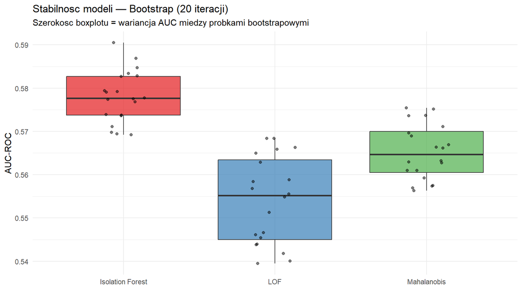

```r
final_stats %>%
  pivot_longer(everything(), names_to="Model", values_to="AUC") %>%
  mutate(Model=recode(Model, m_auc="Mahalanobis",
                      if_auc="Isolation Forest", lof_auc="LOF")) %>%
  ggplot(aes(Model, AUC, fill=Model)) +
  geom_boxplot(alpha=0.7) + geom_jitter(width=0.15, alpha=0.5, size=1.5) +
  scale_fill_brewer(palette="Set1") + theme_minimal() +
  theme(legend.position="none") +
  labs(title="Stabilnosc modeli — Bootstrap (20 iteracji)",
       subtitle="Szerokosc boxplotu = wariancja AUC miedzy probkami bootstrapowymi",
       y="AUC-ROC", x=NULL)
```

# 20 Analiza Sprawiedliwosci Algorytmicznej (Fairness)

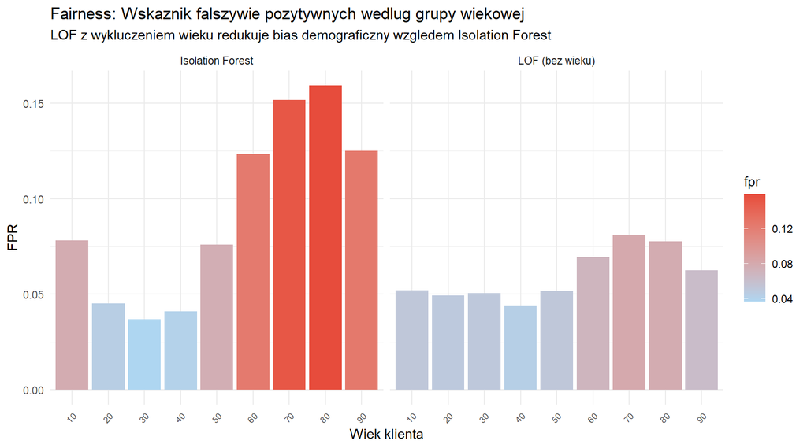

```r
calculate_fairness <- function(test_data, scores, k=0.05) {
  thr  <- quantile(scores, 1-k, na.rm=TRUE)
  pred <- ifelse(scores >= thr, 1, 0)
  test_data %>%
    mutate(pred=pred, actual=ifelse(fraud_bool=="Fraud",1,0)) %>%
    filter(actual==0) %>%
    group_by(customer_age) %>%
    summarise(total=n(), fp=sum(pred), fpr=fp/total, .groups="drop")
}

bind_rows(
  calculate_fairness(df_test_raw, score_iof) %>% mutate(model="Isolation Forest"),
  calculate_fairness(df_test_raw, score_lof) %>% mutate(model="LOF (bez wieku)")
) %>%
  ggplot(aes(factor(customer_age), fpr, fill=fpr)) +
  geom_col() +
  scale_fill_gradient(low="#aed6f1", high="#e74c3c") +
  facet_wrap(~model) + theme_minimal() +
  theme(axis.text.x=element_text(angle=45, hjust=1, size=7)) +
  labs(title="Fairness: Wskaznik falszywie pozytywnych wedlug grupy wiekowej",
       subtitle="LOF z wykluczeniem wieku redukuje bias demograficzny wzgledem Isolation Forest",
       x="Wiek klienta", y="FPR")
```

**Interpretacja:** Isolation Forest wykazuje wyzszy FPR dla grup wiekowych 60-70+ niz LOF z wykluczonym wiekiem. Paradoksalnie, wysoki recall dla seniorow i wysoki FPR dla tej samej grupy dowodzą ,że rzadkosc demograficzna jest interpretowana jako anomalia przez oba modele, co przekłada się na podwyższenie false-postive. —

# 21 Analiza Bledow Modeli — Paradoks Demograficzny

## 21.1 Fraud rate wedlug grupy wiekowej

```r
df_clean %>%
  mutate(age_group=cut(customer_age, breaks=c(0,30,40,50,60,70,100),
                       labels=c("<30","30-40","40-50","50-60","60-70","70+"))) %>%
  group_by(age_group) %>%
  summarise(n_total=n(), n_fraud=sum(fraud_bool=="Fraud"),
            fraud_rate=round(mean(fraud_bool=="Fraud")*100,2), .groups="drop") %>%
  kable(caption="Fraud rate per grupa wiekowa — caly zbior") %>%
  kable_styling(bootstrap_options=c("striped","hover"), full_width=FALSE)
```

Fraud rate per grupa wiekowa — caly zbior

| age_group | n_total | n_fraud | fraud_rate |
| --- | --- | --- | --- |
| <30 | 578275 | 3868 | 0.67 |
| 30-40 | 238712 | 2876 | 1.20 |
| 40-50 | 140353 | 2805 | 2.00 |
| 50-60 | 34770 | 1149 | 3.30 |
| 60-70 | 6517 | 263 | 4.04 |
| 70+ | 1373 | 68 | 4.95 |